# Accidents Data Set

In my recent project, I worked with a comprehensive UK road accident dataset comprising over 300,000 records collected between 2021 and 2022. The scale and richness of this dataset make it highly valuable for data-driven decision-making in road safety and urban planning. To extract actionable insights, I used python to apply the K-Means clustering algorithm, a widely used unsupervised machine learning technique, to categorize the accidents into two key dimensions:

## 1. Clustering by Accident Severity

Accidents were grouped based on their severity, classified into three official categories. I enhanced interpretability by assigning distinct color-coded clusters: 🟣 Slight (85.5%)– Minor accidents with minimal impact 🟠 Serious (13.2%)– Moderate severity requiring medical attention 🟡 Fatal (1.3%)– High-impact or deadly accidents This severity-based clustering allows authorities to identify high-risk areas and allocate resources accordingly.

## 2. Clustering by Geographic Location.

Using latitude and longitude, I segmented accident locations into four spatial clusters aligned with compass directions. These help visualize regional accident patterns across the UK:. 🟡 South East (↘️) – Including areas around London and Kent\n 🔵 South West (↙️) – Covering Cornwall, Devon, and surrounding counties\n 🟠 Central (⏺) – Midlands and surrounding inland regions\n 🟣 North (↑) – Encompassing Northern England and parts of Scotland\n This geographical segmentation highlights regional trends and supports location-specific safety strategies.\n By combining severity-based and location-based clustering, this project provides valuable insight into where and how severely accidents occur—offering guidance for emergency response planning, policy decisions, and road safety improvements.

```python
import numpy as np
import pandas as pd
import matplotlib.pyplot as plt
import seaborn as sns
from sklearn.cluster import KMeans
from sklearn.preprocessing import LabelEncoder
import plotly.express as px
import warnings
warnings.filterwarnings("ignore")
```

```python
df= pd.read_excel("C:/Users/Mohah/Desktop/stat/New folder/Road Accident Data.xlsx")
df.head()
```

|  | Accident_Index | Accident Date | Month | Year | Day_of_Week | Junction_Control | Junction_Detail | Accident_Severity | Latitude | Light_Conditions | ... | Number_of_Casualties | Number_of_Vehicles | Police_Force | Road_Surface_Conditions | Road_Type | Speed_limit | Time | Urban_or_Rural_Area | Weather_Conditions | Vehicle_Type |
| --- | --- | --- | --- | --- | --- | --- | --- | --- | --- | --- | --- | --- | --- | --- | --- | --- | --- | --- | --- | --- | --- |
| 0 | 200901BS70001 | 2021-01-01 | Jan | 2021 | Thursday | Give way or uncontrolled | T or staggered junction | Serious | 51.512273 | Daylight | ... | 1 | 2 | Metropolitan Police | Dry | One way street | 30 | 15:11:00 | Urban | Fine no high winds | Car |
| 1 | 200901BS70002 | 2021-01-05 | Jan | 2021 | Monday | Give way or uncontrolled | Crossroads | Serious | 51.514399 | Daylight | ... | 11 | 2 | Metropolitan Police | Wet or damp | Single carriageway | 30 | 10:59:00 | Urban | Fine no high winds | Taxi/Private hire car |
| 2 | 200901BS70003 | 2021-01-04 | Jan | 2021 | Sunday | Give way or uncontrolled | T or staggered junction | Slight | 51.486668 | Daylight | ... | 1 | 2 | Metropolitan Police | Dry | Single carriageway | 30 | 14:19:00 | Urban | Fine no high winds | Taxi/Private hire car |
| 3 | 200901BS70004 | 2021-01-05 | Jan | 2021 | Monday | Auto traffic signal | T or staggered junction | Serious | 51.507804 | Daylight | ... | 1 | 2 | Metropolitan Police | Frost or ice | Single carriageway | 30 | 08:10:00 | Urban | Other | Motorcycle over 500cc |
| 4 | 200901BS70005 | 2021-01-06 | Jan | 2021 | Tuesday | Auto traffic signal | Crossroads | Serious | 51.482076 | Darkness - lights lit | ... | 1 | 2 | Metropolitan Police | Dry | Single carriageway | 30 | 17:25:00 | Urban | Fine no high winds | Car |

5 rows × 23 columns

```python
df.info()
```

```
<class 'pandas.core.frame.DataFrame'>
RangeIndex: 307973 entries, 0 to 307972
Data columns (total 23 columns):
 #   Column                      Non-Null Count   Dtype
---  ------                      --------------   -----
 0   Accident_Index              307973 non-null  object
 1   Accident Date               307973 non-null  datetime64[ns]
 2   Month                       307973 non-null  object
 3   Year                        307973 non-null  int64
 4   Day_of_Week                 307973 non-null  object
 5   Junction_Control            307973 non-null  object
 6   Junction_Detail             307973 non-null  object
 7   Accident_Severity           307973 non-null  object
 8   Latitude                    307973 non-null  float64
 9   Light_Conditions            307973 non-null  object
 10  Local_Authority_(District)  307973 non-null  object
 11  Carriageway_Hazards         5424 non-null    object
 12  Longitude                   307973 non-null  float64
 13  Number_of_Casualties        307973 non-null  int64
 14  Number_of_Vehicles          307973 non-null  int64
 15  Police_Force                307973 non-null  object
 16  Road_Surface_Conditions     307656 non-null  object
 17  Road_Type                   306439 non-null  object
 18  Speed_limit                 307973 non-null  int64
 19  Time                        307956 non-null  object
 20  Urban_or_Rural_Area         307973 non-null  object
 21  Weather_Conditions          301916 non-null  object
 22  Vehicle_Type                307973 non-null  object
dtypes: datetime64[ns](1), float64(2), int64(4), object(16)
memory usage: 54.0+ MB
```

```python
df.describe()
```

|  | Accident Date | Year | Latitude | Longitude | Number_of_Casualties | Number_of_Vehicles | Speed_limit |
| --- | --- | --- | --- | --- | --- | --- | --- |
| count | 307973 | 307973.000000 | 307973.000000 | 307973.000000 | 307973.000000 | 307973.000000 | 307973.000000 |
| mean | 2021-12-23 22:19:39.804722944 | 2021.468934 | 52.487005 | -1.368884 | 1.356882 | 1.829063 | 38.866037 |
| min | 2021-01-01 00:00:00 | 2021.000000 | 49.914488 | -7.516225 | 1.000000 | 1.000000 | 10.000000 |
| 25% | 2021-06-28 00:00:00 | 2021.000000 | 51.485248 | -2.247937 | 1.000000 | 1.000000 | 30.000000 |
| 50% | 2021-12-08 00:00:00 | 2021.000000 | 52.225943 | -1.349258 | 1.000000 | 2.000000 | 30.000000 |
| 75% | 2022-06-25 00:00:00 | 2022.000000 | 53.415517 | -0.206810 | 1.000000 | 2.000000 | 50.000000 |
| max | 2022-12-31 00:00:00 | 2022.000000 | 60.598055 | 1.759398 | 48.000000 | 32.000000 | 70.000000 |
| std | NaN | 0.499035 | 1.339011 | 1.356092 | 0.815857 | 0.710477 | 14.032933 |

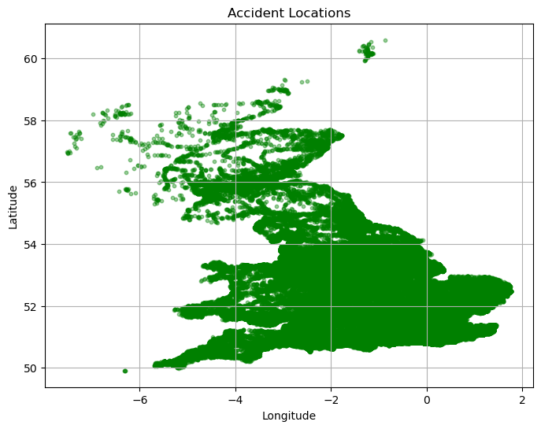

```python
plt.figure(figsize=(8, 6))
plt.scatter(df['Longitude'], df['Latitude'], alpha=0.4, s=10, c='Green')
plt.title('Accident Locations')
plt.xlabel('Longitude')
plt.ylabel('Latitude')
plt.grid(True)
plt.show()
```

```python
df['Accident_Severity'] = df['Accident_Severity'].map({'Serious':'Serious','Slight':'Slight','Fatal':'Fatal','fatal':'Fatal'})
```

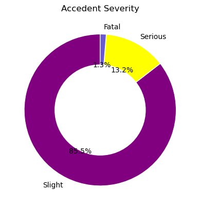

```python
# Accident Severity
types = df.value_counts('Accident_Severity')
colors = ['purple','yellow','#6A5ACD']
plt.pie(types, labels=types.index, autopct='%1.1f%%', startangle=90,colors=colors, wedgeprops={'edgecolor': 'white'})

# Draw a white circle at the center to create the "donut" effect
center_circle = plt.Circle((0,0), 0.6, fc='white')
plt.gca().add_artist(center_circle)
plt.title('Accedent Severity')
```

## K-Means Model

```python
geo_df = df[['Latitude', 'Longitude', 'Accident_Severity']].dropna()

encoder = OneHotEncoder()
X_encoded = encoder.fit_transform(geo_df[['Accident_Severity']])
```

[output not shown]

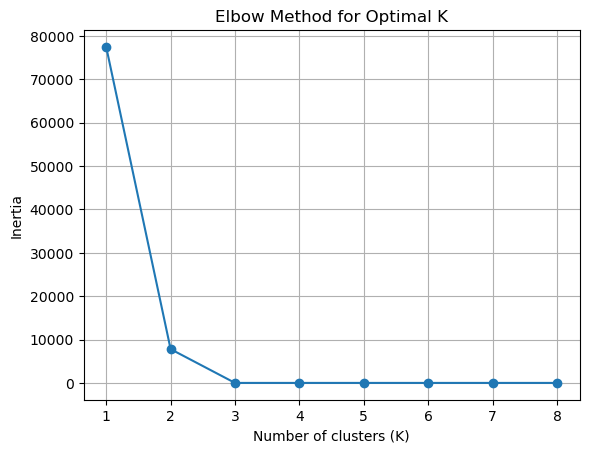

```python
inertia = []
k_range = range(1, 9)

for k in k_range:
    km = KMeans(n_clusters=k, random_state=42)
    km.fit(X_encoded)
    inertia.append(km.inertia_)

plt.plot(k_range, inertia, marker='o')
plt.title('Elbow Method for Optimal K')
plt.xlabel('Number of clusters (K)')
plt.ylabel('Inertia')
plt.grid(True)
plt.show()
```

```python
# 1. Clustering by LOCATION
# --------------------------
geo_df_loc = df[['Latitude', 'Longitude']].dropna()
X_loc = geo_df_loc[['Latitude', 'Longitude']].values

kmeans_loc = KMeans(n_clusters=4, random_state=42)
geo_df_loc['Cluster_Location'] = kmeans_loc.fit_predict(X_loc)

# Create map for Location-based Clusters
fig1 = px.scatter_mapbox(
    geo_df_loc,
    lat='Latitude',
    lon='Longitude',
    color='Cluster_Location',
    zoom=4,
    height=800,
    title='Clusters Based on Accident Location',
    hover_data={'Cluster_Location': True}
)

fig1.update_layout(mapbox_style='open-street-map')
fig1.write_html('location_clusters_map.html')

# --------------------------
# 2. Clustering by SEVERITY
# --------------------------
geo_df_sev = df[['Latitude', 'Longitude', 'Accident_Severity']].dropna()

le = LabelEncoder()
severity_encoded = le.fit_transform(geo_df_sev['Accident_Severity'])
X_sev = severity_encoded.reshape(-1, 1)

kmeans_sev = KMeans(n_clusters=3, random_state=42)
geo_df_sev['Cluster_Severity'] = kmeans_sev.fit_predict(X_sev)

# Create map for Severity-based Clusters
fig2 = px.scatter_mapbox(
    geo_df_sev,
    lat='Latitude',
    lon='Longitude',
    color='Cluster_Severity',
    zoom=4,
    height=800,
    title='Clusters Based on Accident Severity',
    hover_data=['Accident_Severity', 'Cluster_Severity']
)

fig2.update_layout(mapbox_style='open-street-map')
fig2.write_html('severity_clusters_map.html')
```

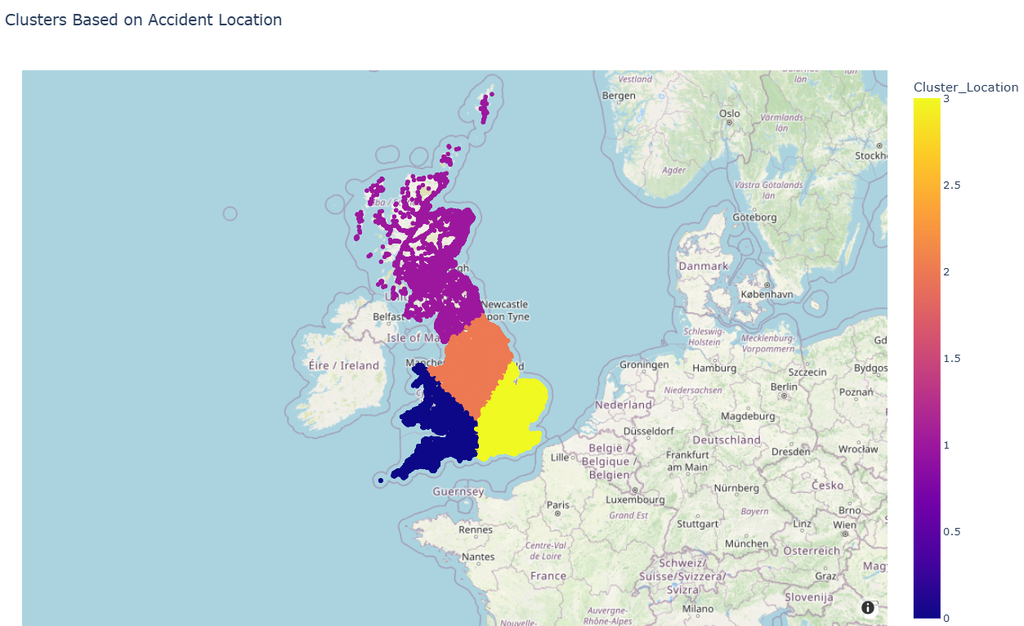

```python
from IPython.display import Image

Image("C:/Users/mohah/Pictures/Screenshots/geo_photo.png")
```

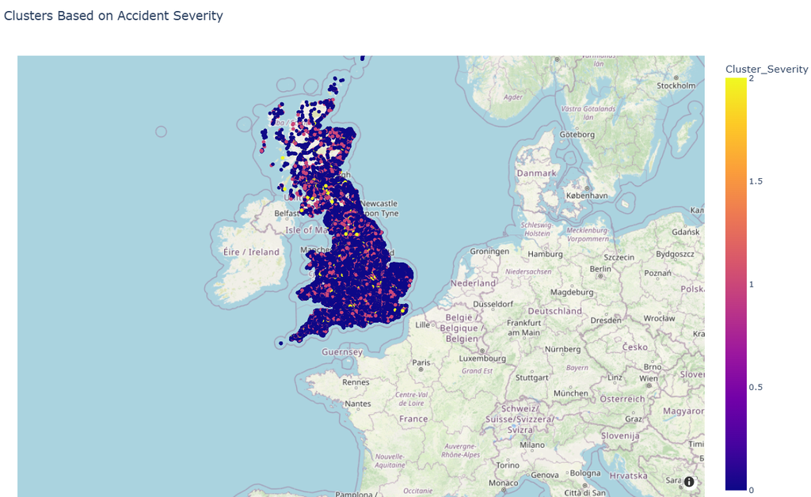

```python
Image("C:/Users/mohah/Pictures/Screenshots/Severity_photo.png")
```